# Clustering Candy Data to Highlight Market Opportunity

| competitorname | chocolate | fruity | caramel | peanutyalmondy | nougat | crispedricewafer | hard | bar | pluribus | sugarpercent | pricepercent | winpercent |
| --- | --- | --- | --- | --- | --- | --- | --- | --- | --- | --- | --- | --- |
| 100 Grand | 1 | 0 | 1 | 0 | 0 | 1 | 0 | 1 | 0 | 0.732 | 0.860 | 66.97173 |
| 3 Musketeers | 1 | 0 | 0 | 0 | 1 | 0 | 0 | 1 | 0 | 0.604 | 0.511 | 67.60294 |
| One dime | 0 | 0 | 0 | 0 | 0 | 0 | 0 | 0 | 0 | 0.011 | 0.116 | 32.26109 |
| One quarter | 0 | 0 | 0 | 0 | 0 | 0 | 0 | 0 | 0 | 0.011 | 0.511 | 46.11650 |
| Air Heads | 0 | 1 | 0 | 0 | 0 | 0 | 0 | 0 | 0 | 0.906 | 0.511 | 52.34146 |
| Almond Joy | 1 | 0 | 0 | 1 | 0 | 0 | 0 | 1 | 0 | 0.465 | 0.767 | 50.34755 |
| Baby Ruth | 1 | 0 | 1 | 1 | 1 | 0 | 0 | 1 | 0 | 0.604 | 0.767 | 56.91455 |
| Boston Baked Beans | 0 | 0 | 0 | 1 | 0 | 0 | 0 | 0 | 1 | 0.313 | 0.511 | 23.41782 |
| Candy Corn | 0 | 0 | 0 | 0 | 0 | 0 | 0 | 0 | 1 | 0.906 | 0.325 | 38.01096 |
| Caramel Apple Pops | 0 | 1 | 1 | 0 | 0 | 0 | 0 | 0 | 0 | 0.604 | 0.325 | 34.51768 |

[output cut: 75 more lines]

```
##
## Confirming all features have zero missing values:
```

```
##
##  chocolate , Missing Values:  0
##  fruity , Missing Values:  0
##  caramel , Missing Values:  0
##  peanutyalmondy , Missing Values:  0
##  nougat , Missing Values:  0
##  crispedricewafer , Missing Values:  0
##  hard , Missing Values:  0
##  bar , Missing Values:  0
##  pluribus , Missing Values:  0
##  sugarpercent , Missing Values:  0
##  pricepercent , Missing Values:  0
```

#### Exploratory Data Analysis

- Correlation Plot shows that variables are correlated to one another alluding to the idea that PCA might be particularly useful. Along with these correlated relationships, there might be latent relationships as well, lets see if we can use PCA to reduce dimensionality.

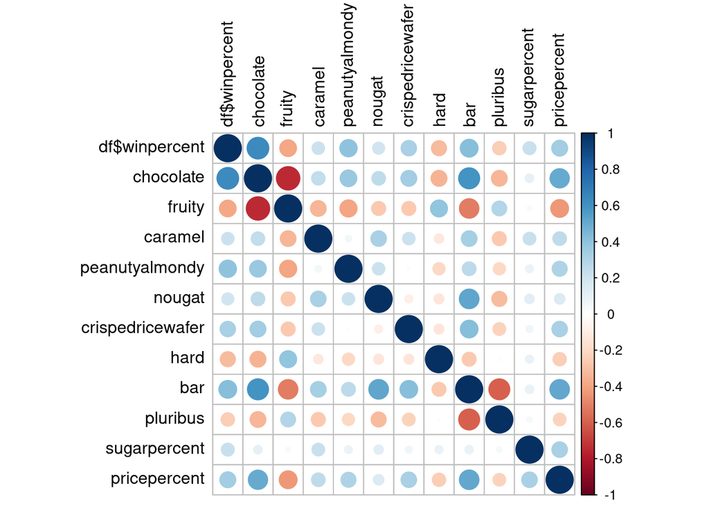

- There are some positive correlations between bar, chocolate, and nougat. We also see some strong negative correlations between bar and fruity, as well as bar and pluribus

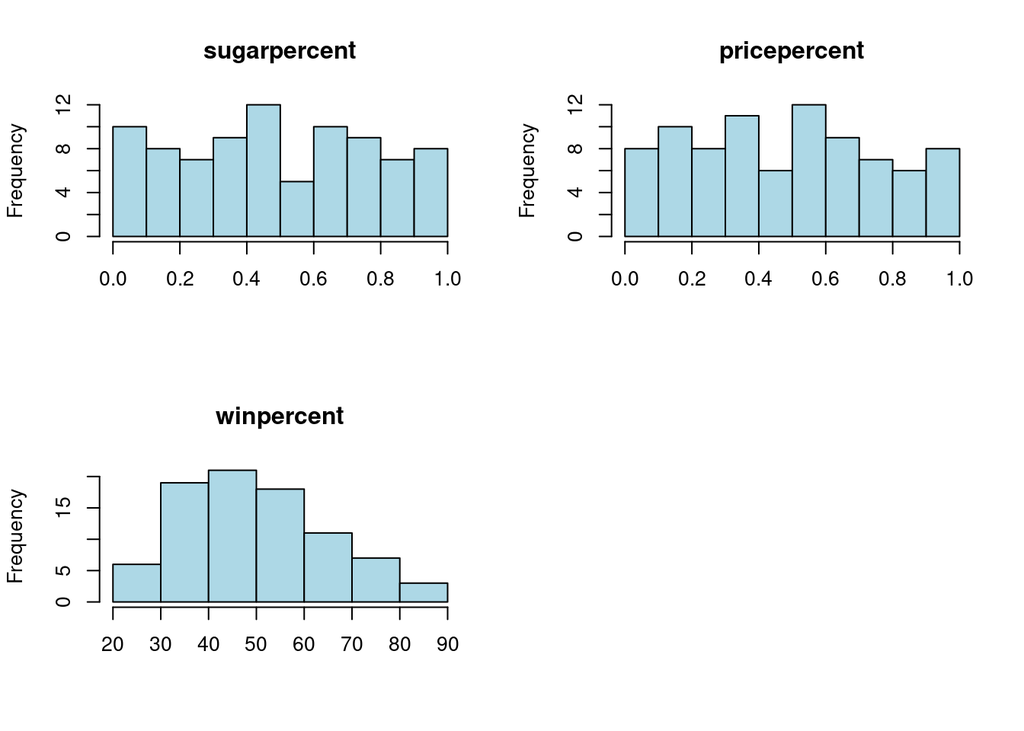

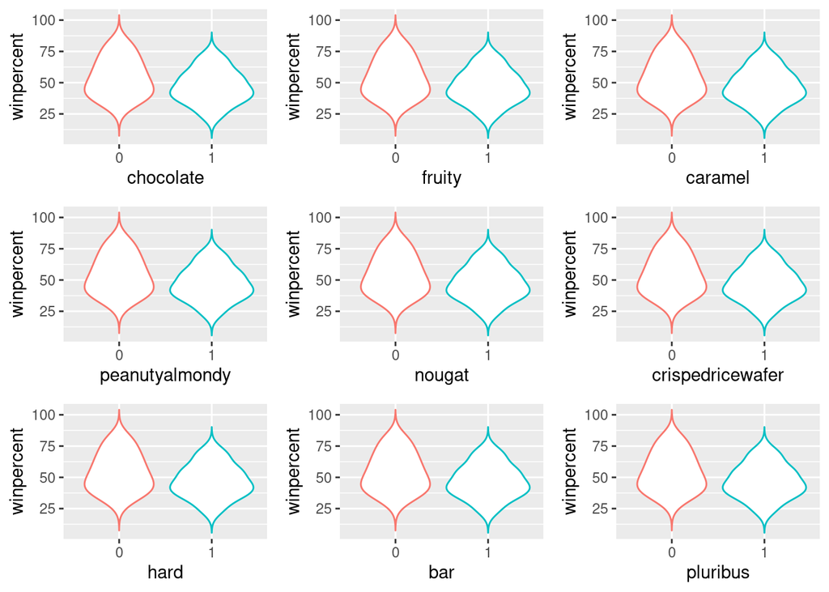

#### PCA Attempt

```
## Importance of components:
##                           PC1    PC2    PC3     PC4     PC5     PC6     PC7
## Standard deviation     1.1874 0.8465 0.4781 0.36587 0.34003 0.33306 0.27738
## Proportion of Variance 0.4737 0.2407 0.0768 0.04497 0.03885 0.03727 0.02585
## Cumulative Proportion  0.4737 0.7145 0.7913 0.83624 0.87509 0.91236 0.93821
##                            PC8     PC9    PC10    PC11
## Standard deviation     0.24708 0.24081 0.20289 0.15399
## Proportion of Variance 0.02051 0.01948 0.01383 0.00797
## Cumulative Proportion  0.95872 0.97820 0.99203 1.00000
```

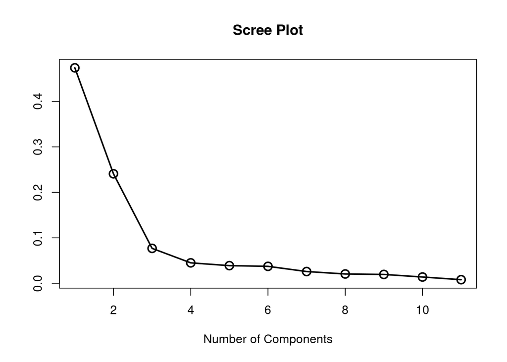

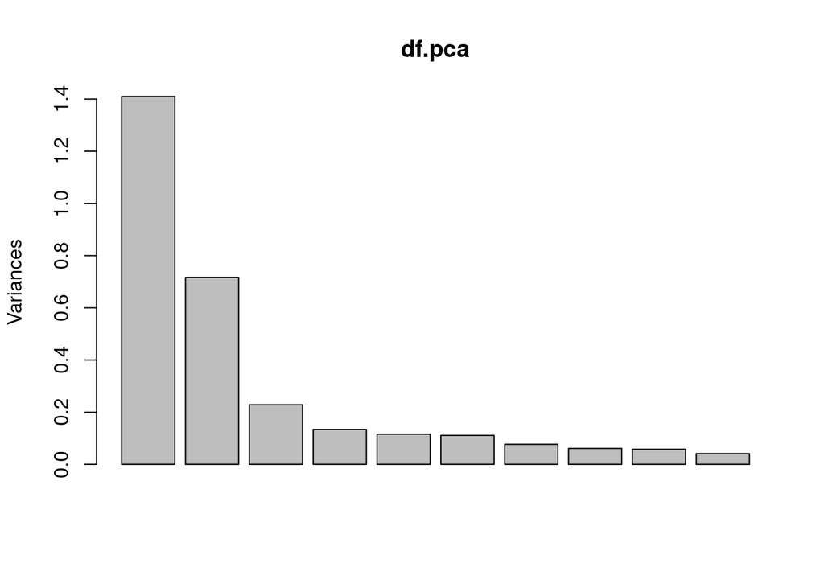

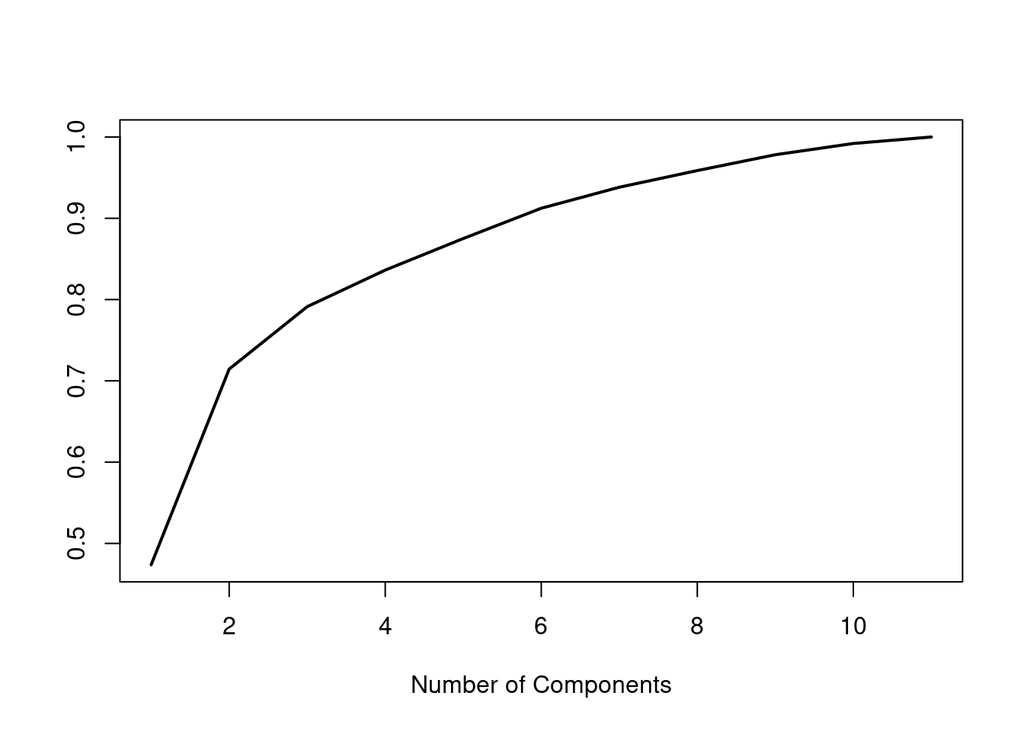

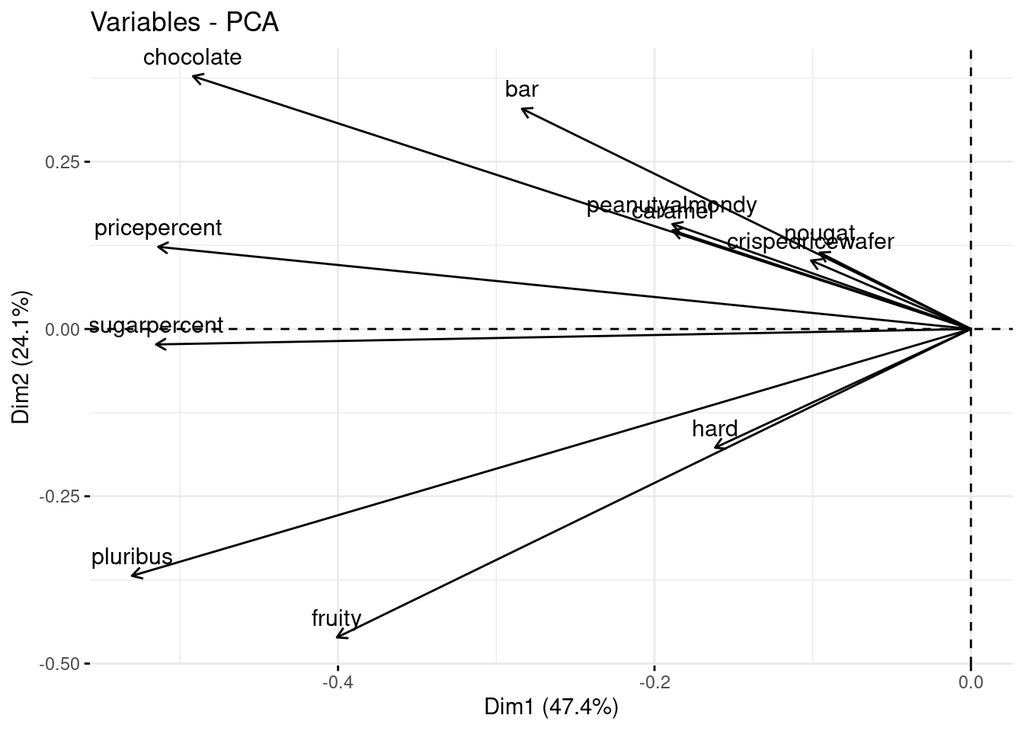

- The scree plot, along with the visuals highlighting explained variance indicates that the first two PCAs can represent most of our data set (~71%).

#### Below we take a look at some elbow plots to give us an idea of the appropriate amount of clusters needed

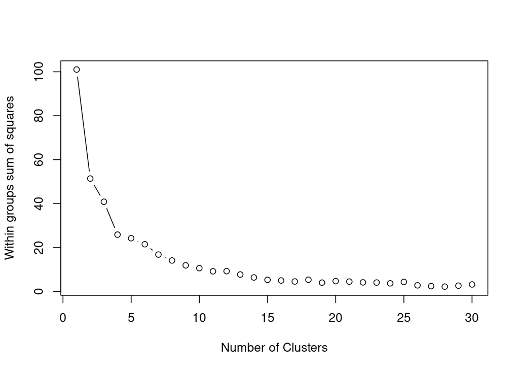

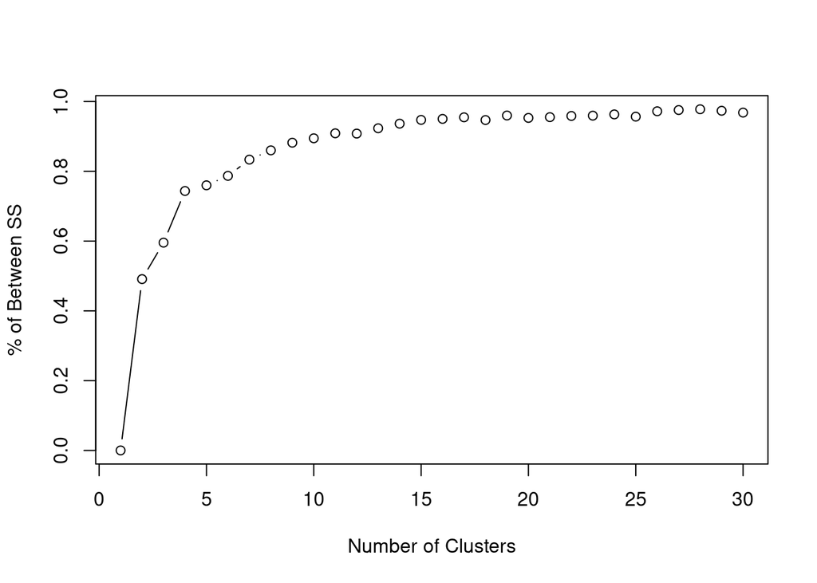

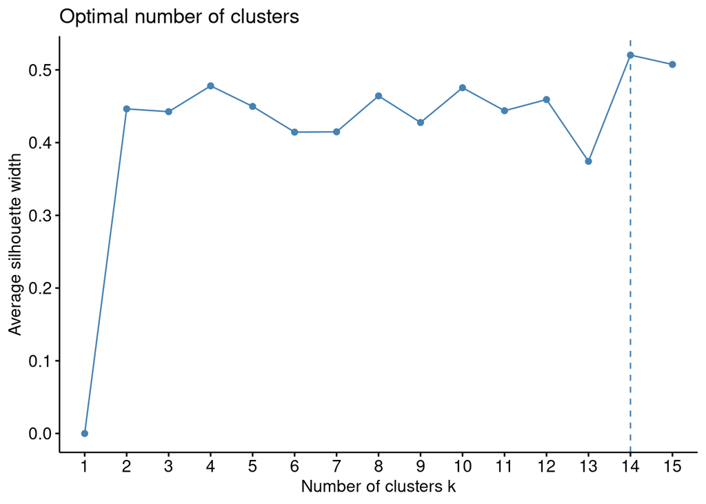

#### We will also leverage brute force calculation to test accuracy as cluster count increases

```
## Accuracy for 1 clusters:  0 %
## Accuracy for 2 clusters:  49 %
## Accuracy for 3 clusters:  59 %
## Accuracy for 4 clusters:  74 %
## Accuracy for 5 clusters:  76 %
## Accuracy for 6 clusters:  77 %
## Accuracy for 7 clusters:  78 %
## Accuracy for 8 clusters:  80 %
## Accuracy for 9 clusters:  82 %
## Accuracy for 10 clusters:  87 %
```

- we see that around 4 clusters the differences in accuracy begin to drop significantly. I chose 4 clusters as I felt comfortable with the accuracy score

#### Below we visualize the 4 clusters leverage the first two principal components which explain around 71% of variance within our data set

|  | Dim.1 | Dim.2 | Dim.3 | Dim.4 | Dim.5 | Dim.6 | Dim.7 | Dim.8 | Dim.9 | Dim.10 | Dim.11 | cluster |
| --- | --- | --- | --- | --- | --- | --- | --- | --- | --- | --- | --- | --- |
| 1 | -1.59780312 | 1.23769705 | 0.444428946 | -0.747963931 | -0.31904348 | 0.164414784 | 0.50136357 | 0.04609892 | -0.246144674 | 0.18412056 | -0.002232112 | 4 |
| 2 | -1.22103473 | 1.02865470 | 0.323018552 | 0.036765816 | -0.18144104 | -0.244277001 | -0.83800828 | 0.18643044 | 0.280644306 | 0.14102215 | -0.232078224 | 4 |
| 3 | -0.04707097 | 0.01578122 | 0.003430215 | 0.003237749 | -0.00910321 | -0.007784737 | 0.03143247 | 0.02783045 | 0.009204403 | -0.07924575 | -0.032888559 | 1 |
| 4 | -0.22414746 | 0.07514866 | 0.016334358 | 0.015417851 | -0.04334862 | -0.037070174 | 0.14967843 | 0.13252594 | 0.043830487 | -0.37736069 | -0.156612179 | 1 |
| 5 | -0.95895415 | -0.49434650 | 0.567054439 | 0.071498082 | -0.03796746 | -0.356403758 | 0.37277822 | 0.01987341 | 0.581140521 | 0.07893956 | -0.072342466 | 1 |
| 6 | -1.35248889 | 1.12143025 | 0.031491121 | 0.733177893 | 0.03362292 | -0.223264272 | 0.10423890 | 0.05387390 | -0.115718045 | -0.09483953 | 0.342311119 | 4 |

|  | eigenvalue | variance.percent | cumulative.variance.percent |
| --- | --- | --- | --- |
| Dim.1 | 1.41 | 47.37 | 47.37 |
| Dim.2 | 0.72 | 24.07 | 71.45 |
| Dim.3 | 0.23 | 7.68 | 79.13 |
| Dim.4 | 0.13 | 4.50 | 83.62 |
| Dim.5 | 0.12 | 3.88 | 87.51 |
| Dim.6 | 0.11 | 3.73 | 91.24 |

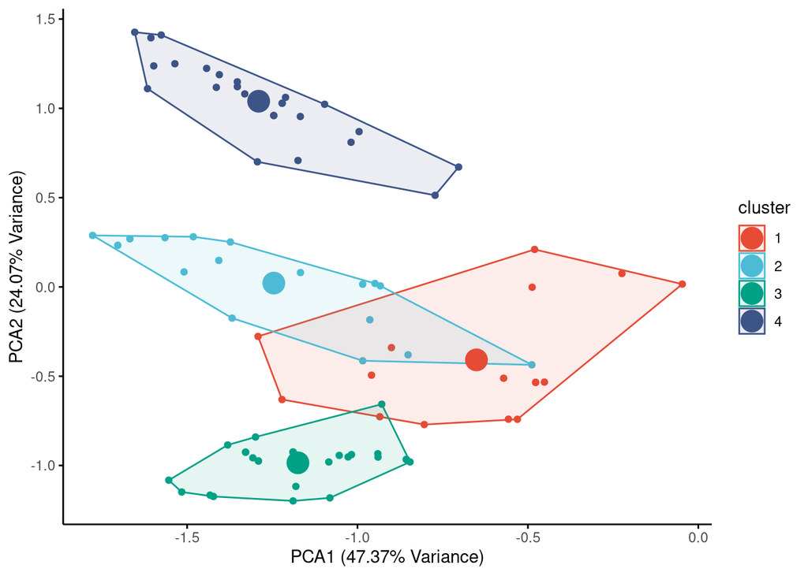

| cluster_id | n | chocolate | fruity | caramel | bar | peanutyalmondy | nougat | winpercent | sugarpercent |
| --- | --- | --- | --- | --- | --- | --- | --- | --- | --- |
| 1 | 16 | 0.0625000 | 0.750000 | 0.1875000 | 0.00 | 0.0000000 | 0.00 | 40.46972 | 0.3715000 |
| 2 | 17 | 0.7058824 | 0.000000 | 0.1764706 | 0.00 | 0.2352941 | 0.00 | 49.93830 | 0.4947059 |
| 3 | 27 | 0.0000000 | 0.962963 | 0.0000000 | 0.00 | 0.0000000 | 0.00 | 44.86116 | 0.4886667 |
| 4 | 25 | 0.9600000 | 0.000000 | 0.3200000 | 0.84 | 0.4000000 | 0.28 | 62.76828 | 0.5254800 |